# Data Driving Risk Management and Customer Segmentation for Vehicle Insurance Optimization

## 1. Background

The Automotive Insurance Analytics program is designed to optimize many operational areas of automotive insurance, including risk assessment and claims management, customer segmentation, education, and security initiatives. Auto insurance is an important part of personal financial planning because it protects you from financial losses caused by accidents, thefts, and other disasters. Insurers, on the other hand, must combine profitability with competitive premiums. To investigate this complex dynamic, the study employed a vast dataset that included precise information about insurance plans, customer demographics, vehicle characteristics, and claims history.

## 2. Describe the Data Sets

```python
import pandas as pd
import seaborn as sns
import matplotlib.pyplot as plt

data = pd.read_csv('car_insurance.csv')
data.head()
```

|  | id | age | gender | driving_experience | education | income | credit_score | vehicle_ownership | vehicle_year | married | children | postal_code | annual_mileage | vehicle_type | speeding_violations | duis | past_accidents | outcome |
| --- | --- | --- | --- | --- | --- | --- | --- | --- | --- | --- | --- | --- | --- | --- | --- | --- | --- | --- |
| 0 | 569520 | 3 | 0 | 0-9y | high school | upper class | 0.629027 | 1.0 | after 2015 | 0.0 | 1.0 | 10238 | 12000.0 | sedan | 0 | 0 | 0 | 0.0 |
| 1 | 750365 | 0 | 1 | 0-9y | none | poverty | 0.357757 | 0.0 | before 2015 | 0.0 | 0.0 | 10238 | 16000.0 | sedan | 0 | 0 | 0 | 1.0 |
| 2 | 199901 | 0 | 0 | 0-9y | high school | working class | 0.493146 | 1.0 | before 2015 | 0.0 | 0.0 | 10238 | 11000.0 | sedan | 0 | 0 | 0 | 0.0 |
| 3 | 478866 | 0 | 1 | 0-9y | university | working class | 0.206013 | 1.0 | before 2015 | 0.0 | 1.0 | 32765 | 11000.0 | sedan | 0 | 0 | 0 | 0.0 |
| 4 | 731664 | 1 | 1 | 10-19y | none | working class | 0.388366 | 1.0 | before 2015 | 0.0 | 0.0 | 32765 | 12000.0 | sedan | 2 | 0 | 1 | 1.0 |

### 2.1 Age and Driving Experience Distribution

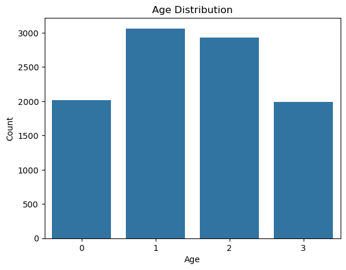

```python
sns.countplot(data=data, x='age')
plt.title('Age Distribution')
plt.xlabel('Age')
plt.ylabel('Count')
plt.show()
```

The histogram above shows that most of drivers are between 25 to 50 years old, which are age group 1 and 2 in datasets.

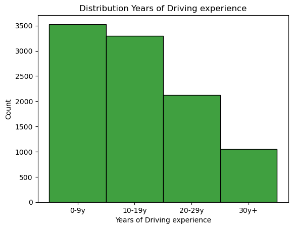

```python
sns.histplot(data['driving_experience'], color='green')
plt.title('Distribution Years of Driving experience')
plt.xlabel('Years of Driving experience')
plt.ylabel('Count')
plt.show()
```

The histogram shows that most insurance customers have 0–9 years of driving experience. Additionally, the number of customers with 10–19 years of driving experience is not significantly different from those with 0–9 years. Based on this information, car insurance companies can consider the following actions:

Targeting Young and Inexperienced Drivers: Since younger drivers, particularly those newly licensed, are more prone to accidents due to lack of experience, the company can develop safety education programs tailored to young drivers based on their age and driving experience. As a risk reduction strategy, higher premium rates can be applied to drivers in the early stages of their driving careers.

Incentives for Young Drivers: The company can offer incentives, such as premium discounts, to young drivers who complete safe driving courses. This can encourage better driving habits and reduce risk.

Retaining Experienced Drivers: To retain experienced drivers, who are generally more cautious on the road, the company could provide special bonuses or discounts. For example, loyalty rewards can be given to drivers with a claim-free record over a specified period.

### 2.2 The Relationship Between Customer Income and Education Level

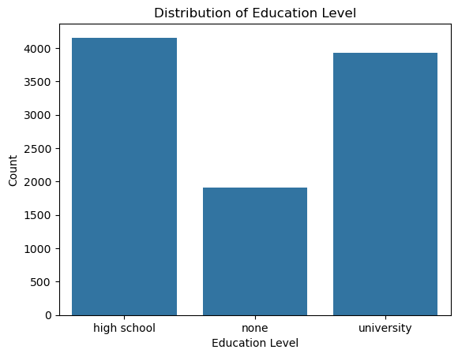

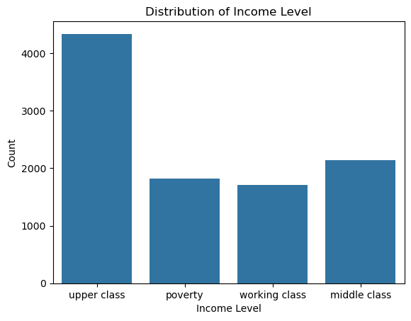

```python
sns.countplot(data=data, x='education')
plt.xlabel('Education Level')
plt.ylabel('Count')
plt.title('Distribution of Education Level')
plt.show()

sns.countplot(data=data, x='income')
plt.xlabel('Income Level')
plt.ylabel('Count')
plt.title('Distribution of Income Level')
plt.show()
```

The Income Level histogram illustrates the distribution of income levels among customers, and the Education Level histogram illustrates that most of insurance customers has university or high school education. The majority of individuals belong to the upper class, with a significantly higher count compared to other income groups. The counts for customers in the povertym working class, and middle class categories are relatively similar, with no significant differences between these groups. However, they are all substantially lower than the count for the upper class.

#### Insights and Recommendations:

1.Focus on Targeting Different Income Groups: Since the upper class constitutes the largest segment, services or products designed for high-income individuals could be a primary focus. Tailored programs for lower-income groups (poverty and working class) could also help address their specific needs and increase engagement.

2.Opportunities for Middle-Class Engagement: The middle class, being slightly larger than the poverty and working-class groups, could be a potential growth market for products or services aimed at upwardly mobile individuals.

3.Addressing Poverty and Working Class: Outreach programs or affordable solutions for those in the poverty and working-class categories might improve overall equity and inclusivity.

#### Analysis of the Correlation Between Education Level and Income Level

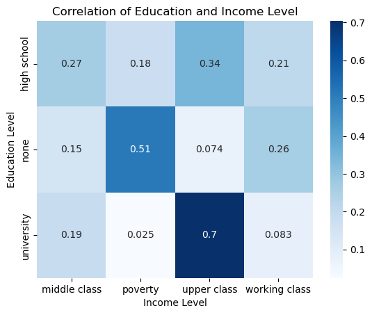

```python
crosstab_data = pd.crosstab(data['education'], data['income'], normalize='index')

sns.heatmap(crosstab_data, annot=True, cmap='Blues')
plt.xlabel('Income Level')
plt.ylabel('Education Level')
plt.title('Correlation of Education and Income Level')
plt.show()
```

1. University and Upper Class (0.7):

The highest correlation is observed between individuals with a university degree and the upper-class income level. This indicates that customers with a university education are more likely to have higher incomes.

2. No Education and Poverty (0.51):

A strong correlation exists between individuals without formal education and those in the poverty income level. This suggests that customers without education are more likely to have lower incomes.

3. High School and Upper Class (0.34):

High school education shows a moderate correlation with upper-class income levels, though it is not as strong as the correlation with university education.

4. University and Poverty (0.025):

The very low correlation between having a university degree and poverty indicates that customers with a university education are highly unlikely to belong to the poverty income group.

5. University and Working Class (0.083) / High School and Working Class (0.21):

These correlations suggest that education level has some influence on whether individuals belong to the working class. However, the relationship is not particularly strong.

### 2.3 Relationship Between Credit Rating and Vehicle Ownership

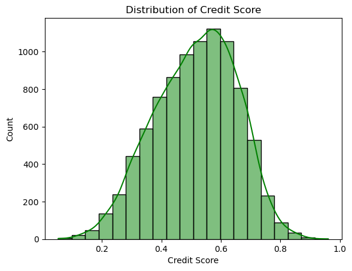

```python
sns.histplot(data['credit_score'], bins=20, kde=True, color='green')
plt.title('Distribution of Credit Score')
plt.xlabel('Credit Score')
plt.ylabel('Count')
plt.show()
```

The histogram illustrates that most of vehicle insurance customers with credit score around 0.6.

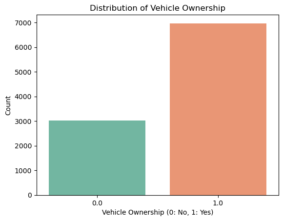

```python
sns.countplot(data=data, x='vehicle_ownership', palette='Set2')
plt.title('Distribution of Vehicle Ownership')
plt.xlabel('Vehicle Ownership (0: No, 1: Yes)')
plt.ylabel('Count')
plt.show()
```

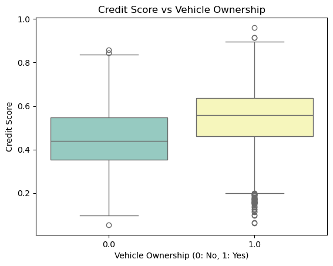

```python
sns.boxplot(x='vehicle_ownership', y='credit_score', data=data, palette='Set3')
plt.title('Credit Score vs Vehicle Ownership')
plt.xlabel('Vehicle Ownership (0: No, 1: Yes)')
plt.ylabel('Credit Score')
plt.show()
```

Customers who own vehicles tend to have higher credit ratings compared to those who do not, although there are more outliers with lower credit scores among vehicle owners. For non-vehicle owners, credit scores fluctuate more widely, whereas vehicle owners’ credit scores tend to cluster around 0.6.

Based on descriptive analysis, consumers with lower credit scores face greater risks and may encounter financial challenges that hinder their ability to maintain their vehicles or avoid filing insurance claims. One possible approach is to charge higher premiums for customers with lower credit scores, as they are more likely to file claims. Flexible premium payment options could be offered for customers unable to pay their premiums in full at once.

Customers who have owned vehicles for a longer time or own certain types of vehicles frequently involved in claims may face additional fees or alternative options. As a preventive measure for high-risk vehicles, companies could offer discounts for routine maintenance to mitigate potential damages.

### 2.4 Relationship Between the Most Popular Vehicle Types and Their Annual Mileage

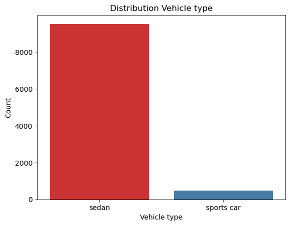

```python
sns.countplot(data=data, x='vehicle_type', palette='Set1')
plt.title('Distribution Vehicle type')
plt.xlabel('Vehicle type')
plt.ylabel('Count')
plt.show()
```

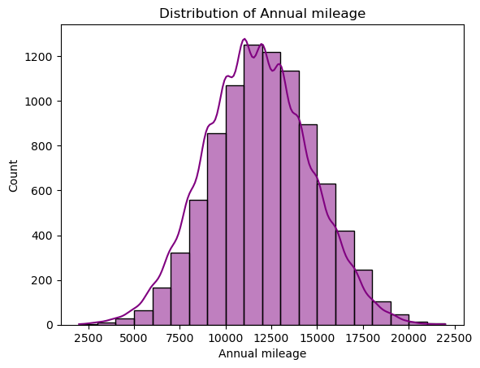

```python
sns.histplot(data['annual_mileage'], bins=20, kde=True, color='purple')
plt.title('Distribution of Annual mileage')
plt.xlabel('Annual mileage')
plt.ylabel('Count')
plt.show()
```

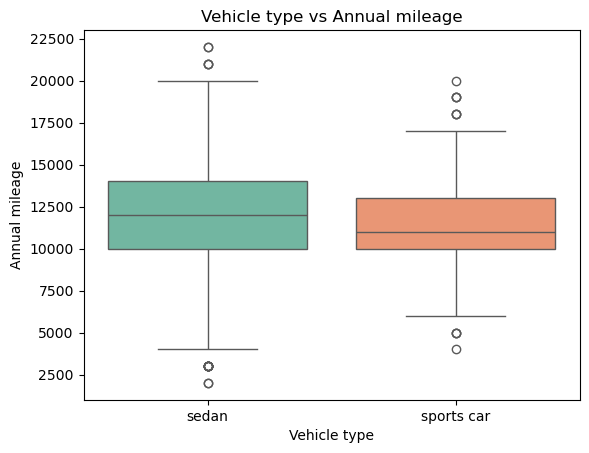

```python
sns.boxplot(x='vehicle_type', y='annual_mileage', data=data, palette='Set2')
plt.title('Vehicle type vs Annual mileage')
plt.xlabel('Vehicle type')
plt.ylabel('Annual mileage')
plt.show()
```

In general, sedans tend to have higher annual mileage and are used more extensively compared to sports cars, which have lower and more stable annual mileage. Some sports car owners may drive their vehicles less frequently, as indicated by low-mileage outliers.

Vehicles with high annual mileage are more likely to experience accidents or damage.

### Recommendations:

1. **Higher Rates for High-Mileage Vehicles**:  
   Implement higher premium rates for high-mileage vehicles due to increased risk.
2. **Maintenance Discounts for High-Mileage Vehicles**:  
   Offer discounts on regular maintenance for customers with high-mileage vehicles, helping them maintain their vehicles and reduce the likelihood of claims.
3. **Adjust Rates for Specific Vehicle Types**:  
   If certain vehicle types (e.g., sedans or sports cars) are associated with higher claim risks, consider raising premiums for those categories.
4. **Risk-Reduction Strategies**:  
   Provide tailored advice to reduce risks, such as specialized training or driving courses designed for specific vehicle types.

## 3. Correlation Analysis

### 3.1 Correlation of Risk Factor and Insurance Claim

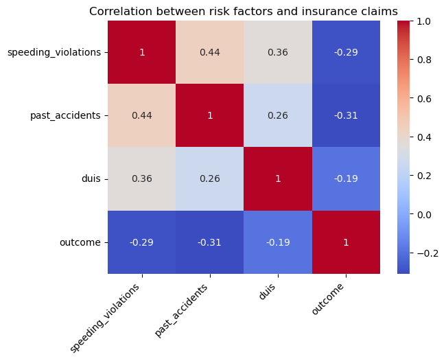

```python
risk_factors = ['speeding_violations', 'past_accidents', 'duis', 'outcome']

correlation_matrix = data[risk_factors].corr()

sns.heatmap(correlation_matrix, annot=True, cmap='coolwarm')
plt.title('Correlation between risk factors and insurance claims')
plt.xticks(rotation=45, ha='right')
plt.show()
```

### 3.2 Distribution of Claims Based on Risk Factors

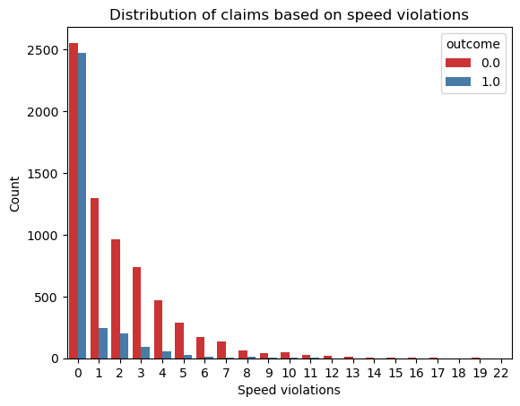

```python
sns.countplot(x='speeding_violations', hue='outcome', data=data, palette='Set1')
plt.xlabel('Speed violations')
plt.ylabel('Count')
plt.title('Distribution of claims based on speed violations')
plt.show()
```

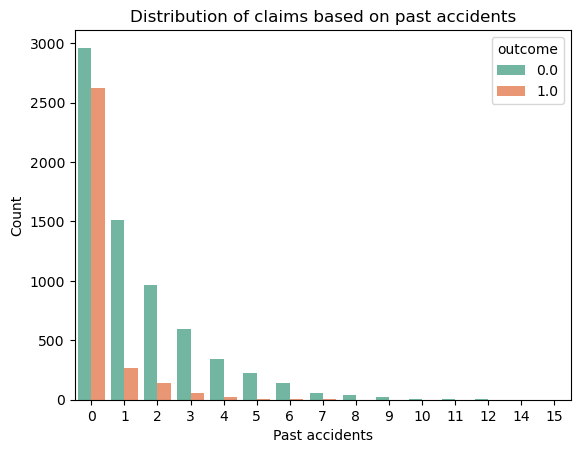

```python
sns.countplot(x='past_accidents', hue='outcome', data=data, palette='Set2')
plt.title('Distribution of claims based on past accidents')
plt.xlabel('Past accidents')
plt.ylabel('Count')
plt.show()
```

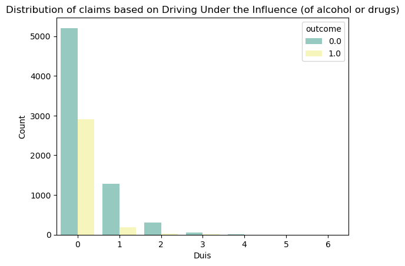

```python
sns.countplot(x='duis', hue='outcome', data=data, palette='Set3')
plt.xlabel('Duis')
plt.ylabel('Count')
plt.title('Distribution of claims based on Driving Under the Influence (of alcohol or drugs)')
plt.show()
```

If traffic violations, past accidents, or DUIs are found to be closely associated with claim outcomes, companies can prioritize prevention by offering driver safety education programs. Additionally, they can develop special premium plans for consumers with a good driving record.

## 4. Customer Segmentation Based on Risk Category

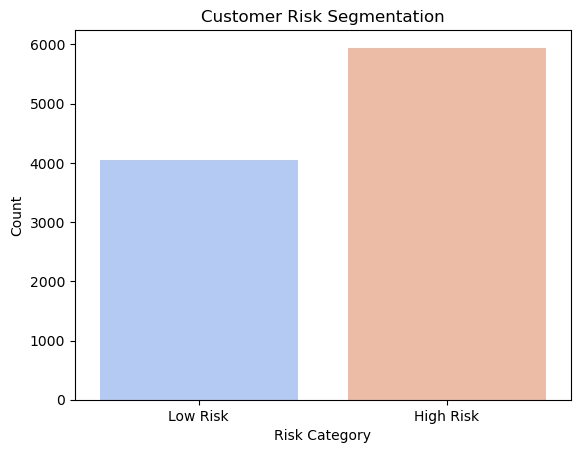

```python
data['risk_category'] = 'Low Risk'
data.loc[(data['speeding_violations'] > 0) | (data['past_accidents'] > 0) | (data['duis'] > 0), 'risk_category'] = 'High Risk'

sns.countplot(x='risk_category', data=data, palette='coolwarm')
plt.title('Customer Risk Segmentation')
plt.xlabel('Risk Category')
plt.ylabel('Count')
plt.show()
```

High-risk categories significantly outnumber low-risk categories. Traffic violations, past accidents, DUIs, credit scores, and age are all risk variables that can be used to classify customers. Customers who frequently violate driving regulations or have a history of accidents may be categorized as high-risk. On the other hand, customers with a clean driving record or a good credit score may be classified as low-risk

## 5. Insurance Claim Analysis

```
outcome
0.0    68.67
1.0    31.33
Name: proportion, dtype: float64
```

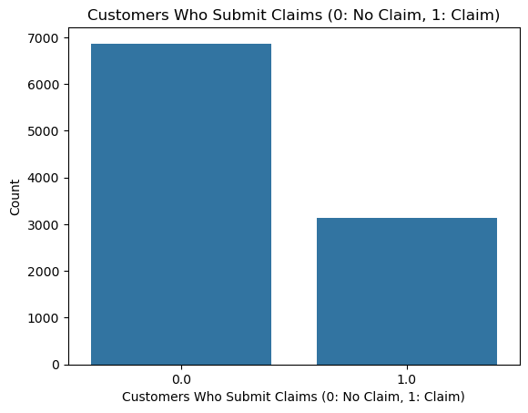

```python
claim_proportion = data['outcome'].value_counts(normalize=True) * 100
print(claim_proportion)

sns.countplot(data=data, x='outcome')
plt.title('Customers Who Submit Claims (0: No Claim, 1: Claim)')
plt.xlabel('Customers Who Submit Claims (0: No Claim, 1: Claim)')
plt.ylabel('Count')
plt.show()
```

The majority of customers fall into the "No Claim" category, with approximately 7,000 entries. This indicates that most customers did not file an insurance claim during the observed period. The imbalance between customers who did and did not submit claims highlights that the majority of insured customers are low-risk or do not encounter incidents requiring claims. Insurance companies could use this data to assess risk factors and identify characteristics of customers who are more likely to file claims.

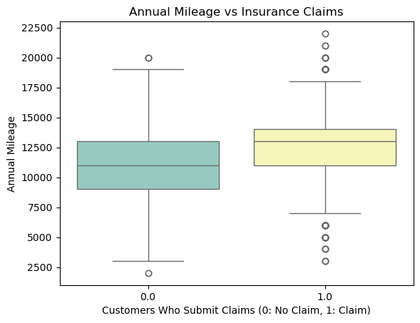

```python
sns.boxplot(x='outcome', y='annual_mileage', data=data, palette='Set3')
plt.title('Annual Mileage vs Insurance Claims')
plt.xlabel('Customers Who Submit Claims (0: No Claim, 1: Claim)')
plt.ylabel('Annual Mileage')
plt.show()
```

[figure not shown]

```python
sns.boxplot(x='outcome', y='vehicle_year', data=data, palette='Set2')
plt.title('Vehicle year vs Insurance Claims')
plt.xlabel('Customers Who Submit Claims (0: No Claim, 1: Claim)')
plt.ylabel('Vehicle year')
plt.show()
```